# Модель, описывающая динамику RMR в зависисомтси от хода болезни при заражении птиц разными видами малярии

Читаем данные

## Зависимая переменная для модели

Будем изучать две зависимые переменные: log(RMR) и D_RMR = log(RMR) - log(RMR<sub>1</sub>). Вторая величина показывает то, насколько отклоняется наблюдаемое значение RMR от начального уровня.

## Пердикторы в модели

В качестве предикторов в модели можно использовать следующие показатели

1. Эксперимент. Дискретный предиктор с тремя уровнями.
2. Текущее значение паразитемии (Parasitemia), оно характеризует инфекцию в момент измерения RMR.
3. Накопленное значение паразитемии (Cum_Parasitemia) хараткеризует “историю” и уровень инфекции. Это, по сути, некоторая оценка численности микрогемипопуляции паразита, побывавшей в организме хозяина на момент измерения RMR.
4. Концентрация итерлейкина в момент измерения RMR (IL) характеризует иммунный ответ в момент измерения RMR.
5. Накопленное значение интерлейкина (Cum_IL) характеризует “историю” и уровень иммунной реакции. То есть это что-то, что говорит о вкладе иммунитета.
6. Масса птицы (Mass) - это “техническая” ковариата.

## Выбор разных способов оценки предикторов в будущей модели для дня измерения RMR

Поскольку для дня измерения RMR нет точного измерения предикторов, то они могут быть предсказаны несколькими способами.

1. Можно взять значение, измеренное в ближайшую к дню измерения RMR дату.
2. Можно построить loess-модель, которая описывает поведение величины в зависисмости от даты. Далее получить предсказание модели для даты измерения RMR.
3. Можно взять две соседние от даты измерения RMR точки (одну до и одну после), далее подобрав парамтеры прямой, проходящей через эти две точки, расчитать значение, которое будет в день измерения RMR.

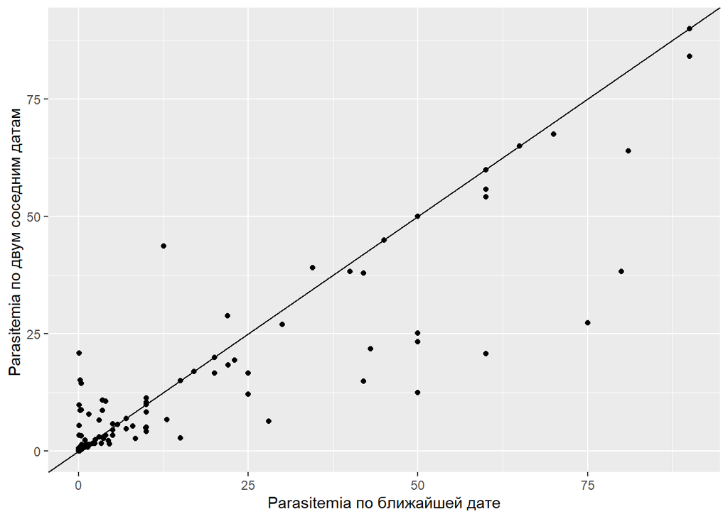

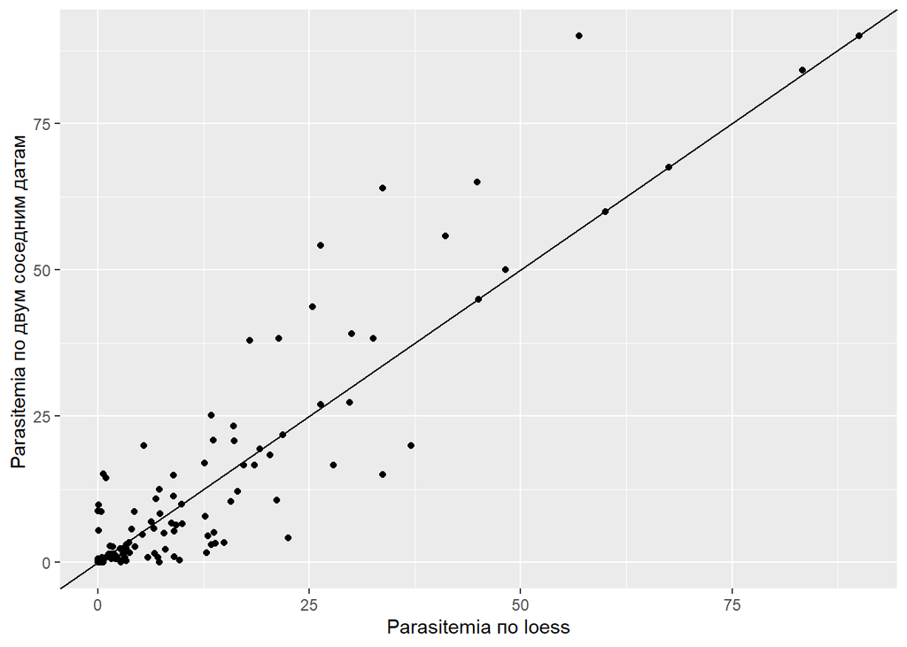

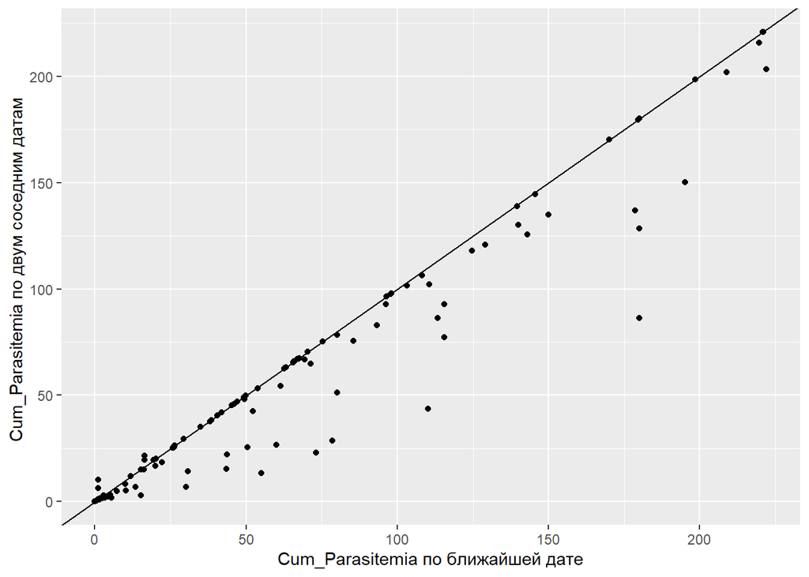

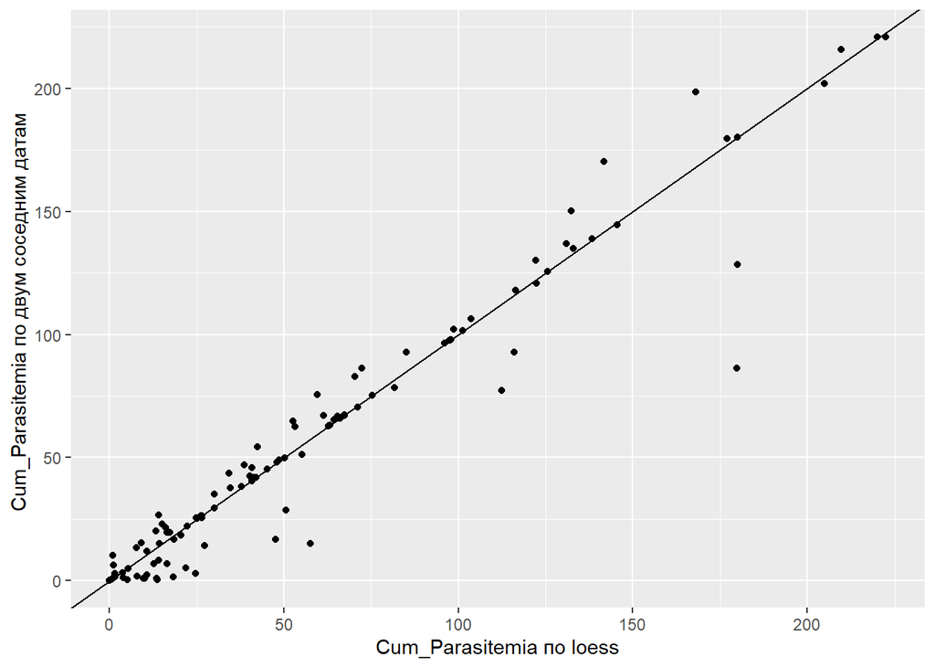

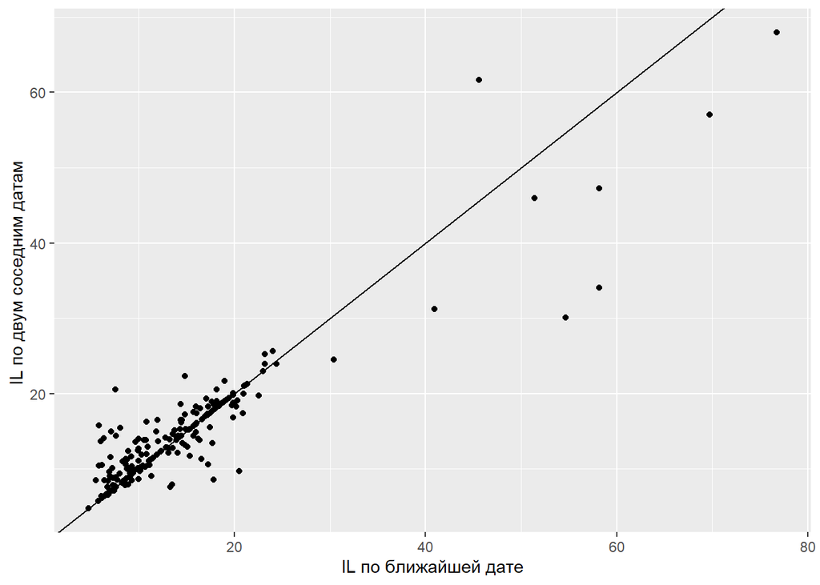

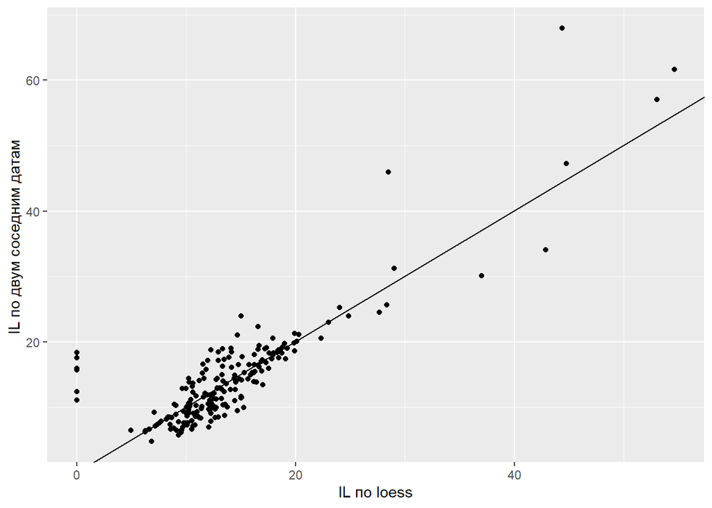

По-моему, принципиальной разницы между способами оценки значений предикторов нет.

Поэтому, для простоты, возьмем оценки по двум соседним точкам.

## Модель для собственно RMR

**Надо подумать.** По сути дела, мы можем построить три типа моделей.

1. Модель, где рассматривается реакция RMR на “историю” болезни. То есть в качестве предикторов выступают накопленные величины инфекции и иммунитета: Cum_Parasitemia, Cum_IL.
2. Модель, где рассматривется реакция RMR на сотояние в инфекции в данное время. То есть в качестве предикторов выступают величины инфекции и иммунитета непосредственно в день измерения RMR: Parasitemia, IL.
3. Модель, где реакция RMR является функцией и от тех и от других типов величин. То есть в качестве предикторов выступают одновременно Parasitemia, Cum_Parasiemia, IL, Cum_IL.

```r
M1_gam <- gam(log(RMR) ~ s(Cum_Parasitemia, by = Experiment)  + s(Cum_IL, by = Experiment) + Experiment + log(Mass)  + s(Ring, k = 53, bs = "re"),  method = "REML", data = finch_reduced)

M2_gam <- gam(log(RMR) ~ s(Parasitemia, by = Experiment)  + s(IL, by = Experiment) + Experiment + log(Mass)  + s(Ring, k = 53, bs = "re"),  method = "REML", data = finch_reduced)

M3_gam <- gam(log(RMR) ~ s(Cum_Parasitemia, by = Experiment) + s(Parasitemia, by = Experiment) + s(IL, by = Experiment) + s(Cum_IL, by = Experiment) + Experiment + log(Mass)  + s(Ring, k = 53, bs = "re"),  method = "REML", data = finch_reduced)
```

```r
AIC(M1_gam, M2_gam, M3_gam)
```

```
##              df       AIC
## M1_gam 48.82506 -390.4828
## M2_gam 45.44017 -364.6554
## M3_gam 64.15590 -377.7846
```

Вот ее параметры

```
##
## Family: gaussian
## Link function: identity
##
## Formula:
## log(RMR) ~ s(Cum_Parasitemia, by = Experiment) + s(Cum_IL, by = Experiment) +
##     Experiment + log(Mass) + s(Ring, k = 53, bs = "re")
##
## Parametric coefficients:
##                 Estimate Std. Error t value Pr(>|t|)
## (Intercept)     1.914316   0.308678   6.202 4.99e-09 ***
## ExperimentExp1 -0.052654   0.141569  -0.372    0.710
## ExperimentExp2 -0.008219   0.141974  -0.058    0.954
## log(Mass)       0.477462   0.107674   4.434 1.76e-05 ***
## ---
## Signif. codes:  0 '***' 0.001 '**' 0.01 '*' 0.05 '.' 0.1 ' ' 1
##
## Approximate significance of smooth terms:
##                                         edf    Ref.df     F p-value
## s(Cum_Parasitemia):ExperimentCont 1.185e-15 1.185e-15 0.000 1.00000
## s(Cum_Parasitemia):ExperimentExp1 1.000e+00 1.000e+00 0.319 0.57296
## s(Cum_Parasitemia):ExperimentExp2 3.060e+00 3.664e+00 4.438 0.00311 **
## s(Cum_IL):ExperimentCont          3.305e+00 4.040e+00 1.332 0.27343
## s(Cum_IL):ExperimentExp1          1.696e+00 2.073e+00 5.912 0.00309 **
## s(Cum_IL):ExperimentExp2          1.001e+00 1.002e+00 1.034 0.31055
## s(Ring)                           3.027e+01 5.000e+01 1.844 < 2e-16 ***
## ---
## Signif. codes:  0 '***' 0.001 '**' 0.01 '*' 0.05 '.' 0.1 ' ' 1
##
## Rank: 110/111
## R-sq.(adj) =  0.488   Deviance explained = 60.1%
## -REML = -160.59  Scale est. = 0.0063406  n = 197
```

Диагностика

```
##
## Method: REML   Optimizer: outer newton
## full convergence after 11 iterations.
## Gradient range [-3.362127e-05,0.0003673347]
## (score -160.5923 & scale 0.006340649).
## Hessian positive definite, eigenvalue range [6.661331e-15,96.17292].
## Model rank =  110 / 111
##
## Basis dimension (k) checking results. Low p-value (k-index<1) may
## indicate that k is too low, especially if edf is close to k'.
##
##                                         k'      edf k-index p-value
## s(Cum_Parasitemia):ExperimentCont 9.00e+00 1.19e-15    1.05    0.72
## s(Cum_Parasitemia):ExperimentExp1 9.00e+00 1.00e+00    1.05    0.72
## s(Cum_Parasitemia):ExperimentExp2 9.00e+00 3.06e+00    1.05    0.68
## s(Cum_IL):ExperimentCont          9.00e+00 3.30e+00    1.04    0.69
## s(Cum_IL):ExperimentExp1          9.00e+00 1.70e+00    1.04    0.64
## s(Cum_IL):ExperimentExp2          9.00e+00 1.00e+00    1.04    0.71
## s(Ring)                           5.30e+01 3.03e+01      NA      NA
```

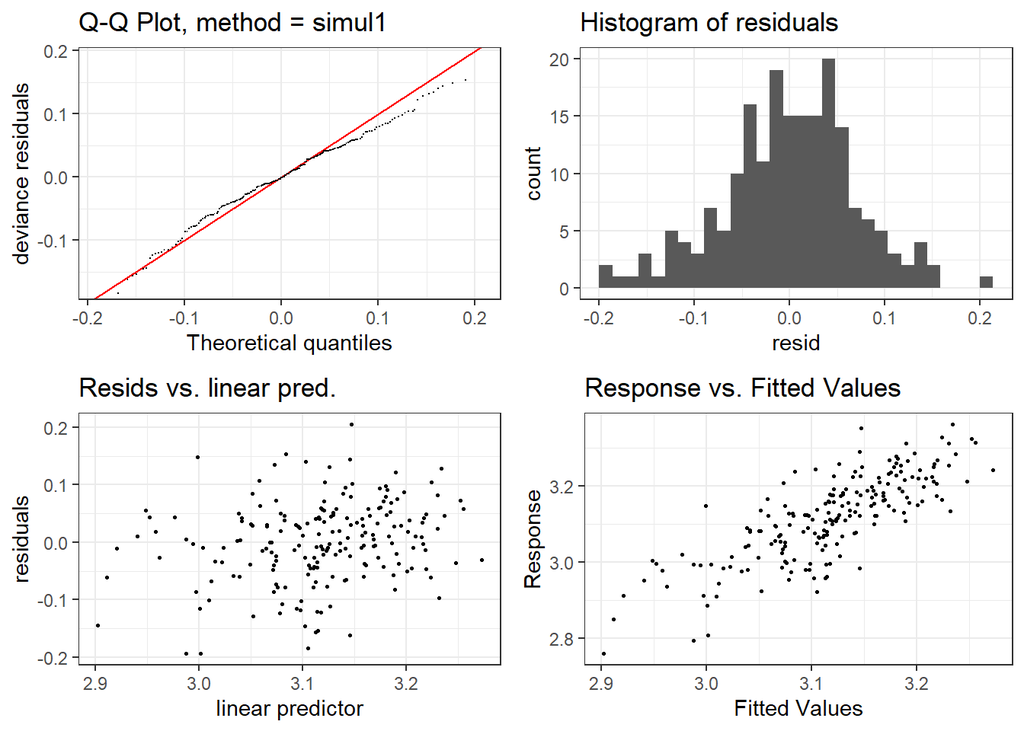

Особых проблем нет.

## Визуализации модели

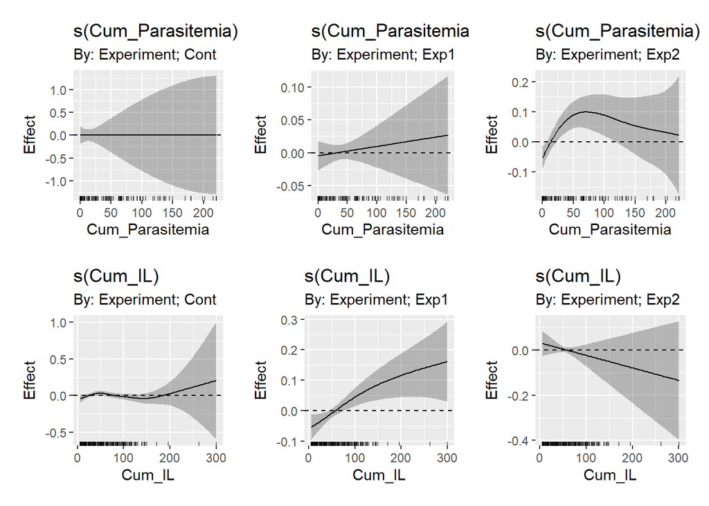

На всякий случай смотрим на связь остатаков с DPI

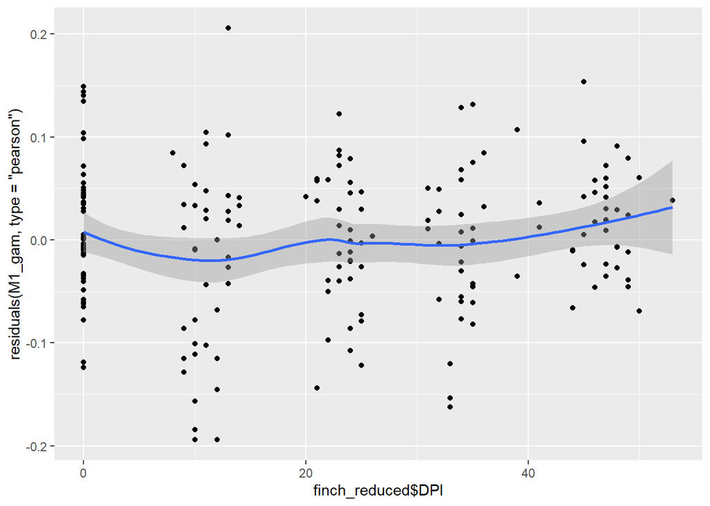

Связи нет, что говорит о том, что ход болезни в терминах накопленной паразитемии и накопленного иммунного ответа вполне описывает процесс.

**Трактовка результатов**

Тут еще надо всем вместе подумать.

Важно, по-моему, что из трех моделй-кандидатов оптимальой оказалась модель, основанная на “истории” болезни, а не на текущем ее состоянии.

Из этой модели получается следующее.

1. В целом, RMR от вида паразита не зависит и не отличается от контроля.
2. RMR растет по мере развития заболевания. Однако при первом виде паразита (Exp1) RMR растет по мере увеличения вклада иммунной системы. Чем больше накопленный сигнал от иммунной системы, тем выше RMR. При втором виде (Exp2) идуктором роста RMR является численность микрогемипопуляции паразита. Большая накопленная паразитемия - больше испорченных эритроцтов.

## Модель для D_RMR

Вот ее параметры

```
##
## Family: gaussian
## Link function: identity
##
## Formula:
## D_RMR ~ s(Cum_Parasitemia, by = Experiment) + s(Cum_IL, by = Experiment) +
##     Experiment + log(Mass) + s(Ring, k = 53, bs = "re")
##
## Parametric coefficients:
##                Estimate Std. Error t value Pr(>|t|)
## (Intercept)    -0.63583    0.28794  -2.208  0.02864 *
## ExperimentExp1 -0.01636    0.13936  -0.117  0.90671
## ExperimentExp2 -0.02813    0.13971  -0.201  0.84070
## log(Mass)       0.26345    0.09886   2.665  0.00849 **
## ---
## Signif. codes:  0 '***' 0.001 '**' 0.01 '*' 0.05 '.' 0.1 ' ' 1
##
## Approximate significance of smooth terms:
##                                          edf     Ref.df     F p-value
## s(Cum_Parasitemia):ExperimentCont -7.903e-16 -7.903e-16 0.000 1.00000
## s(Cum_Parasitemia):ExperimentExp1  1.000e+00  1.000e+00 0.006 0.94098
## s(Cum_Parasitemia):ExperimentExp2  3.041e+00  3.638e+00 4.941 0.00152 **
## s(Cum_IL):ExperimentCont           3.296e+00  4.028e+00 1.583 0.19126
## s(Cum_IL):ExperimentExp1           2.289e+00  2.803e+00 4.512 0.00554 **
## s(Cum_IL):ExperimentExp2           1.002e+00  1.005e+00 0.845 0.35901
## s(Ring)                            2.144e+01  5.000e+01 0.877 0.00055 ***
## ---
## Signif. codes:  0 '***' 0.001 '**' 0.01 '*' 0.05 '.' 0.1 ' ' 1
##
## Rank: 110/111
## R-sq.(adj) =  0.357   Deviance explained = 47.2%
## -REML = -172.12  Scale est. = 0.00622   n = 197
```

Диагностика

[output not shown]

[figure not shown]

Не очень….

## Визуализации модели

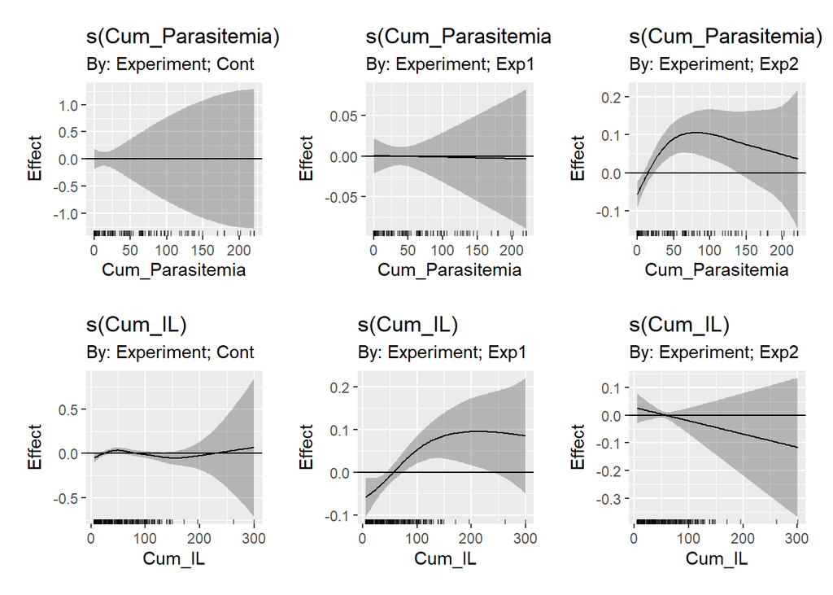

Это аналог того, что было.